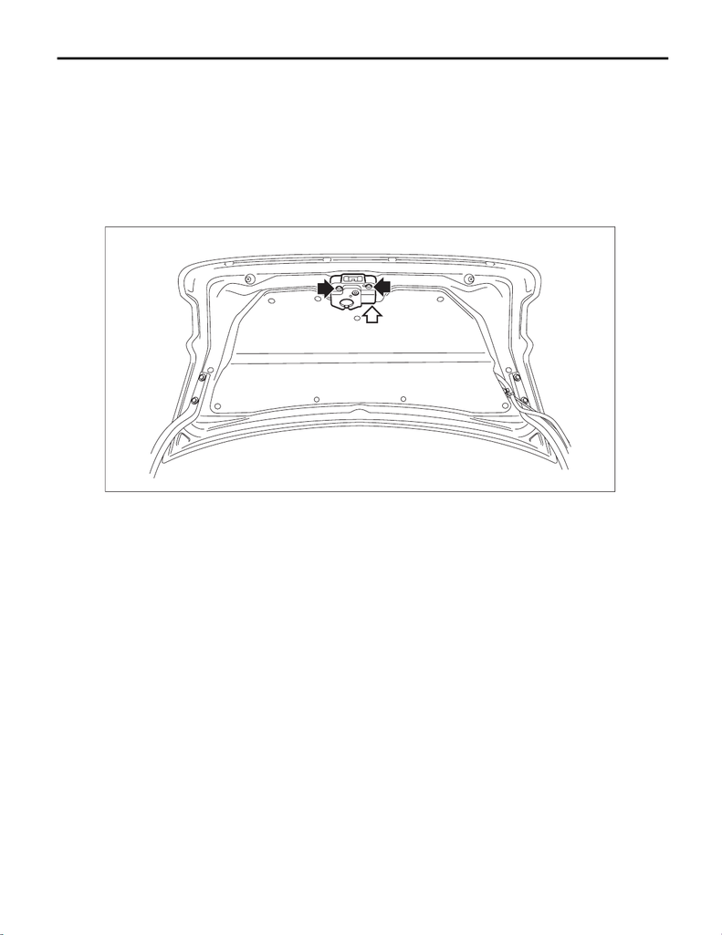

SL-49

Trunk Lid Latch and Actuator Assembly

SECURITY AND LOCKS

15.Trunk Lid Latch and Actuator Assembly

A: REMOVAL

1) Open the trunk lid COMPL.

2) Disconnect the ground cable from battery. <Ref. to NT-5, BATTERY, NOTE, Note.>

NOTE:

For models other than STI model, disconnect the ground terminal from battery sensor.

3) Remove the latch and actuator - trunk lid.

(1) Disconnect the connector.

(2) Remove the bolts, and remove the latch and actuator - trunk lid.

B: INSTALLATION

1) Install the latch and actuator - trunk lid.

Tightening torque:

7.5 N·m (0.8 kgf-m, 5.5 ft-lb)

2) Connect the battery ground terminal. <Ref. to NT-5, BATTERY, NOTE, Note.>

NOTE:

For models other than STI model, connect the ground terminal to battery sensor.

Sl-02865

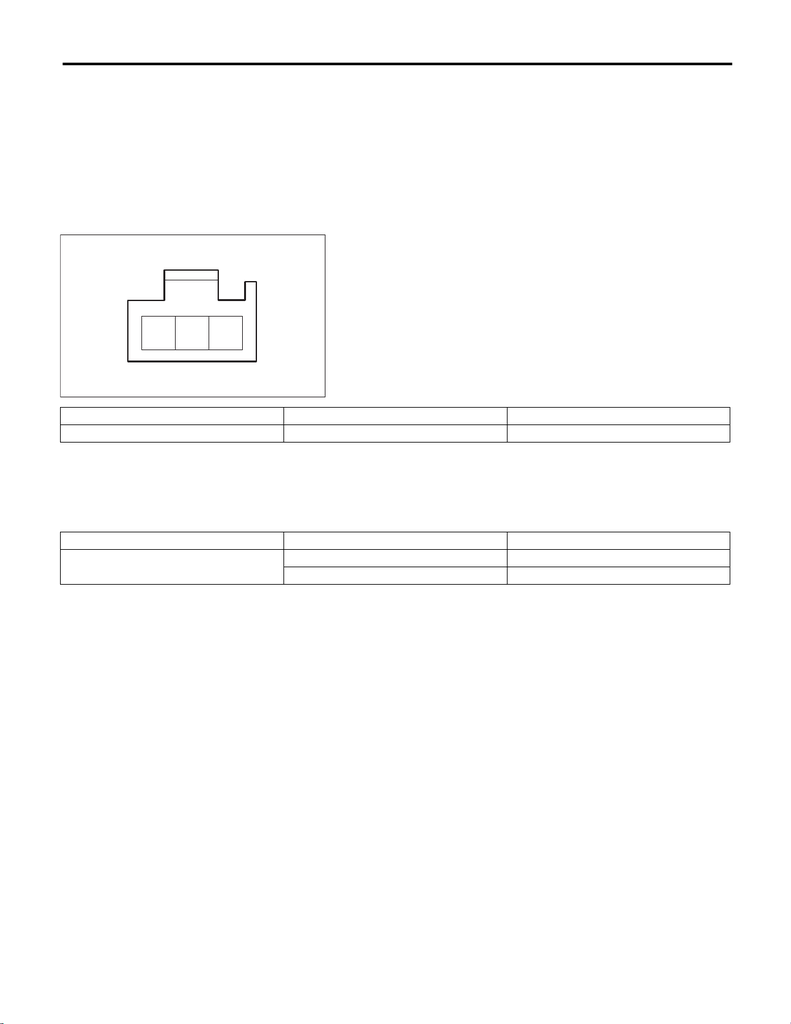

SL-50

Trunk Lid Latch and Actuator Assembly

SECURITY AND LOCKS

C: INSPECTION

1. LATCH

Check if the latch operates normally.

If latch deformation, abnormal wear, or unsmooth lock operation is observed, replace the latch and actuator -

trunk lid.

2. ACTUATOR

1) Check door lock operation

Check the door lock operation when battery voltage is applied between the connectors.

2) Check switch

Measure the resistance between connector terminals.

Preparation tool:

Circuit tester

3) If it does not operate normally, replace the latch and actuator - trunk lid.

SL-02882

3 2 1

Terminal No. Inspection conditions Standard

1 (+) — 2 (–) Connect battery to the terminals LOCK → UNLOCK

Terminal No. Inspection conditions Standard

2 — 3

LOCK 1 MΩ or more

UNLOCK Less than 1 Ω